# Project Python Foundations: FoodHub Data Analysis

# Q6.2 - What is the spread of `food_preparation_time`?

```
The most frequent prep time was 21.0
```

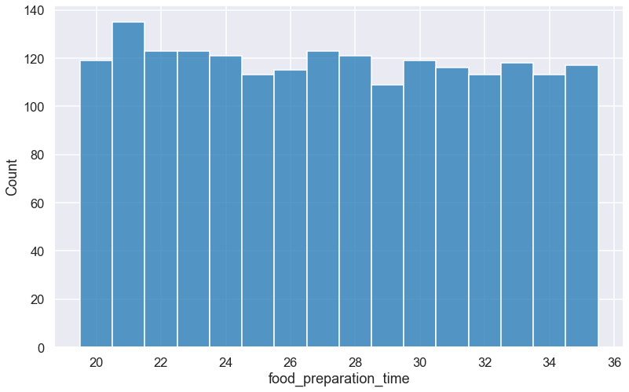

```python
# Histogram plot of food_preparation_time
# Set discrete to True to see each whole minute

plt.figure(figsize=(13, 8))
sns.histplot(df.food_preparation_time, discrete=True);

print("The most frequent prep time was", float(df.food_preparation_time.mode()))
```

# Q6.2 Observation - `food_preparation_time`

- Food prep times are more evenly distributed than previously thought
- The range is from 20 minutes to 35 minutes

# Q6.3 - What is the spread of `delivery_time`?

```
The longest delivery time was 33 minutes
The shortest delivery time was 15 minutes
```

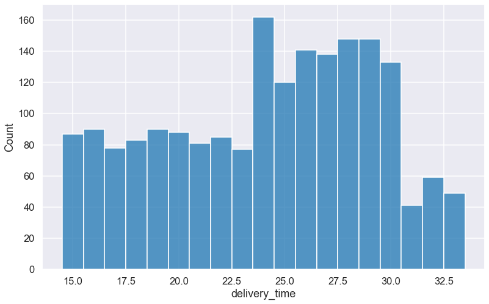

```python
# Histogram plot of delivery_time

plt.figure(figsize=(13, 8))
sns.histplot(df.delivery_time, discrete=True);

print("The longest delivery time was", df.delivery_time.max(),"minutes")
print("The shortest delivery time was", df.delivery_time.min(),"minutes")
```

# Q6.3 Observation - `delivery_time`

- The delivery time also seems pretty evenly distributed with a range from 15 to 33 minutes
- There is a slight increase in the count of delivery times between 24 and 30 minutes
- There is a slight decline near the end with less deliveries taking longer than half an hour

# Q6.4a - What is the distribution of both delivery and food prep time?

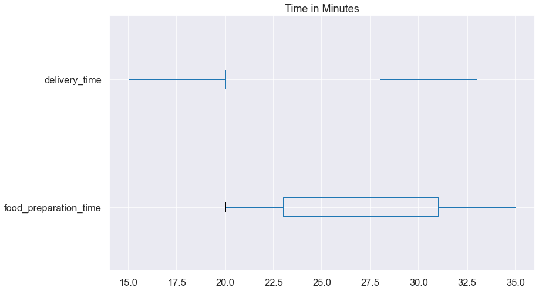

```python
# Box plots of food prep and delivery times

df[['food_preparation_time','delivery_time']].plot(kind='box',
                                                   vert=False,
                                                   title='Time in Minutes',
                                                   figsize=(13,8));
```

# Q6.4a Observation - `food_preparation_time` and `delivery_time`

- The box-and-whisker plots of both food prep and delivery times seem pretty evenly distributed
- No outliers suggests reliable data
- Delivery times are faster than prep times on average, but most often the times are about the same.

# Q6.4b

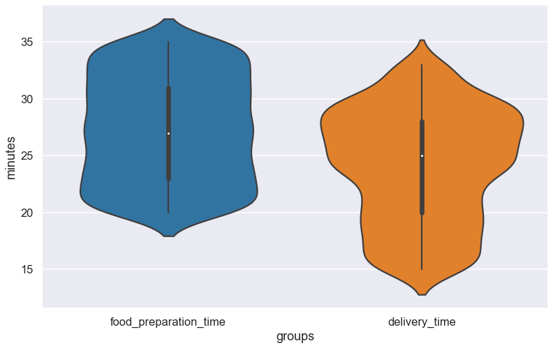

```python
# Violin plots of food prep and delivery times

timedf = df[['food_preparation_time','delivery_time']].melt(var_name='groups', value_name='minutes')
plt.figure(figsize=(13,8))
sns.violinplot(x='groups', y='minutes', data=timedf);
```

# Q6.4b Observation - `food_preparation_time` and `delivery_time`

- Again we see that both times are mostly even and have a large overlap
- Again we see that sometimes the delivery time is faster than food prep times

# Q6.4c

```
The average total order time was 51.53371970495258 minutes
```

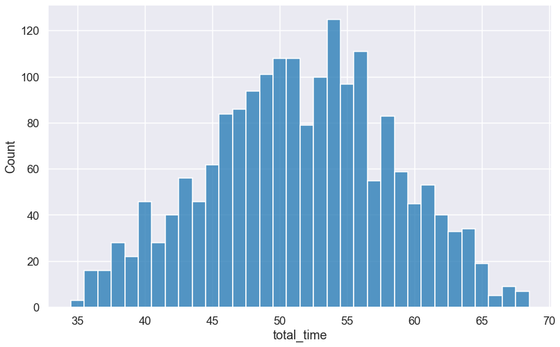

```python
# Add food prep and delivery times and check the distribution of total times

# Create a new column called total_time
df['total_time'] = df['food_preparation_time']+df['delivery_time']

# Plot the histogram of total times
plt.figure(figsize=(13,8))
sns.histplot(df['total_time'], discrete=True);

# Find the average total time
print("The average total order time was", df['total_time'].mean(),"minutes")
```

# Q6.4c Observation - `total_time`

- The total order time (food prep + delivery) appears to have a bell curve shape
- Most orders take between 45 to 60 minutes
- The average total time is 52 minutes

# Q6.5a - What's the count of `cuisine_type`?

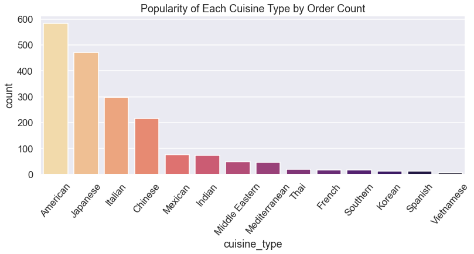

```python
# Count Plot of cuisine_type

plt.figure(figsize=(13, 5))
sns.countplot(df['cuisine_type'], palette='magma_r', order = df['cuisine_type'].value_counts().index)
plt.title("Popularity of Each Cuisine Type by Order Count")
plt.xticks(rotation=50);
plt.savefig("cuisine_count.jpg", bbox_inches='tight')
```

# Q6.5a Observation - `cuisine_type`

- The top 4 cuisines are American, Japanese, Italian, and Chinese
- The other 10 cuisine types have less than 100 orders each
- American is the most popular, even more popular than the trailing 10 types combined

# Q6.5b - Are there any restaurants with more than one cuisine type?

```python
# Check to see if each restaurant is associated with only 1 cuisine type

# Group the restaurants together, then check for the number of unique values in cuisine and sort
df.groupby('restaurant_name').describe(include='all')['cuisine_type']['unique'].sort_values(ascending=False).head()
```

```
restaurant_name
The Meatball Shop            2
'wichcraft                   1
Pepe Rosso To Go             1
Piccolo Angolo               1
Pinto Nouveau Thai Bistro    1
Name: unique, dtype: object
```

```python
# Now we see all restaurants have only 1 cuisine type, except for The Meatball Shop

# For all rows with 'The Meatball Shop', find the value counts of cuisine type
df[df['restaurant_name']=='The Meatball Shop']['cuisine_type'].value_counts()
```

```
Italian           112
American           20
Chinese             0
French              0
Indian              0
Japanese            0
Korean              0
Mediterranean       0
Mexican             0
Middle Eastern      0
Southern            0
Spanish             0
Thai                0
Vietnamese          0
Name: cuisine_type, dtype: int64
```

# Q6.5b Observation - `cuisine_type`

- Each restaurant is associated with 1 cuisine type, except for The Meatball Shop
  - The Meatball shop has been listed as Italian 112 times
  - The Meatball shop has been listed as American 20 times
- This means The Meatball Shop will show up in 2 different categories when grouping by cuisine type.
  - We may want to change them all to "Italian" so there is no overlap

# Q6.6 - How is the data divided by `day_of_the_week`?

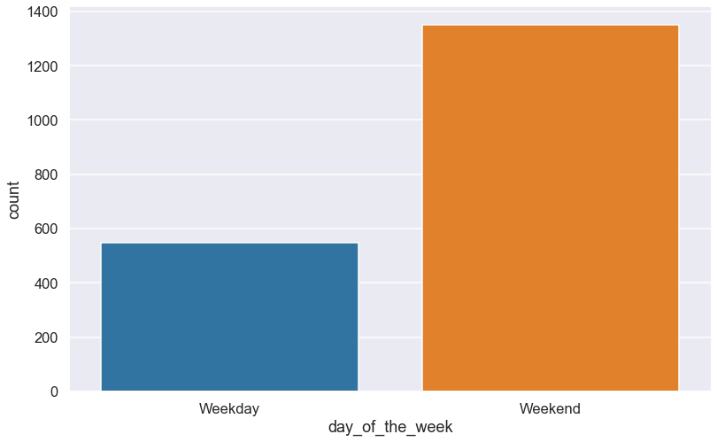

```python
# Count Plot for day of the week

plt.figure(figsize=(13, 8))
sns.countplot(df['day_of_the_week']);
```

# Q6.6 Observation - `day_of_the_week`

- As mentioned before, the dataset consists of far more weekend orders than weekday orders.
- Nearly 2.5 times more orders are placed on the weekend

# Q6.7a - Are all the restaurant names truly unique?

```python
# Display the counts of every restaurant and sort alphabetically to look for similar names

rdf = df[['restaurant_name']].value_counts().sort_index()
rdf.index.tolist()
```

```
[("'wichcraft",),
 ('12 Chairs',),
 ('5 Napkin Burger',),
 ('67 Burger',),
 ('Alidoro',),
 ('Amma',),
 ("Amy Ruth's",),
 ('Anjappar Chettinad',),
 ('Asuka Sushi',),
 ('Aurora',),
 ('Balade',),
 ('Balthazar Boulangerie',),
 ('Barbounia',),
 ('Bareburger',),
 ('Benihana',),
 ('Bhatti Indian Grill',),
 ("Big Daddy's",),
 ('Big Wong Restaurant \x8c_¤¾Ñ¼',),
 ('Bistango',),
 ('Blue Ribbon Brooklyn',),
 ('Blue Ribbon Fried Chicken',),
 ('Blue Ribbon Sushi',),
 ('Blue Ribbon Sushi Bar & Grill',),
 ('Blue Ribbon Sushi Izakaya',),
 ('Boqueria',),
 ("Bubby's ",),
 ('Bukhara Grill',),
 ('Burger Joint',),
 ('Byblos Restaurant',),
 ('Cafe Habana',),
 ('Cafe Mogador',),
 ('Cafe de La Esquina',),
 ('Cafeteria',),
 ('CafÌ© China',),
 ("Carmine's",),
 ('Chipotle Mexican Grill $1.99 Delivery',),
 ('Cho Dang Gol',),
 ('Chola Eclectic Indian Cuisine',),
 ('Chote Nawab',),
 ('Cipriani Le Specialita',),
```

[output cut: 123 more lines]

```
 ('Vezzo Thin Crust Pizza',),
 ('Wa Jeal',),
 ('Waverly Diner',),
 ('Westville Hudson',),
 ('Wo Hop Restaurant',),
 ('Woorijip',),
 ('Xe May Sandwich Shop',),
 ("Xi'an Famous Foods",),
 ('Yama 49',),
 ('Yama Japanese Restaurant',),
 ('Zero Otto Nove',),
 ('brgr',),
 ('da Umberto',),
 ('ilili Restaurant',),
 ('indikitch',)]
```

```python
# There are some similarities
# Find the total of all 5 restaurants that start with "Blue Ribbon" (using indices instead of RegEx)

# Add together the counts for the 5 Blue Ribbon restaurants
blue_sum = rdf.loc[['Blue Ribbon Brooklyn',
 'Blue Ribbon Fried Chicken',
 'Blue Ribbon Sushi',
 'Blue Ribbon Sushi Bar & Grill',
 'Blue Ribbon Sushi Izakaya',]].sum()

print("All 5 Blue Ribbon restaurants combined:", blue_sum)

# Pull the value count for Shake Shack
shsh = int(rdf.loc['Shake Shack'].values)
print("Shake Shack has", shsh, "orders")

# Print the difference between Shake Shack and the Blue Ribbon restaurants combined
diff = blue_sum-shsh
print("The difference is", diff)
```

```
All 5 Blue Ribbon restaurants combined: 292
Shake Shack has 219 orders
The difference is 73
```

# Q6.7a Observation - `restaurant_name`

- If we put the restaurants in alphabetical order, we can see some restaurants that are similarly named
  - Dirty Bird to Go (2)
  - Sarabeth's (4)
  - Vanessa's (2)
  - Blue Ribbon (5)
    - If all 5 were combined into a chain, they would surpass Shake Shack by 73 orders!!!
- For the scope of this assignment, we will assume normality for the restaurant names and not combine or separate them

# Q6.7b - What's the frequency of restaurants?

```
Half of all restaurants have 3 or less orders
90% of restaurants have less than 25 orders
```

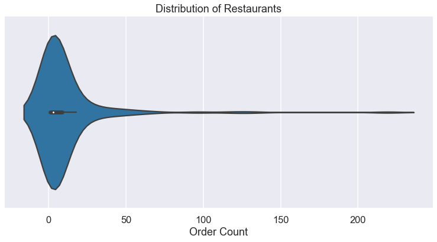

```python
# Violin Plot of frequency of restaurants in the dataset

plt.figure(figsize=(13,6))
sns.violinplot(df.restaurant_name.value_counts());
plt.title("Distribution of Restaurants")
plt.xlabel("Order Count")
plt.savefig("restaurant_count.jpg", bbox_inches='tight')


print("Half of all restaurants have", int(df.restaurant_name.value_counts().median()), "or less orders")
print("90% of restaurants have less than", int(df.restaurant_name.value_counts().quantile(q=.9)), "orders")
```

# Q6.7b Observation - `restaurant_name`

- There are outliers and the frequency is very right-skewed
  - Most restaurants have a small amount of orders
  - A very small amount of restaurants have an extremely high amount of orders
- Half of all restaurants have 3 or less orders
- 90% of restaurants have less than 25 orders

# Q6.8 - What's the spread of ratings?

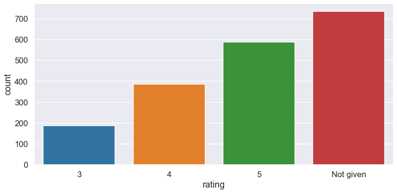

```python
# Count plot for ratings in order from 1 to 5 (including "Not given")

plt.figure(figsize=(13,6))
sns.countplot(df['rating'].sort_values());
plt.savefig("rating_count.jpg", bbox_inches='tight')
```

# Q6.8 Observation - `rating`

- There is a large number of orders not rated
- Most ratings given are 5-star ratings
- Next, 4 stars are given, and then 3 stars are given the least
- There are no 1-star or 2-star ratings in this dataset

### Question 7: Write the code to find the top 5 restaurants that have received the highest number of orders. (1 mark)

```python
# Use .value_counts() to count and display top 5
df['restaurant_name'].value_counts().head(5)
```

```
Shake Shack                  219
The Meatball Shop            132
Blue Ribbon Sushi            119
Blue Ribbon Fried Chicken     96
Parm                          68
Name: restaurant_name, dtype: int64
```

# Q7 Observation:

- The restaurant with the highest orders is Shake Shack at 219 orders
  - Could the Shake Shack numbers be high because it's a chain that includes dozens of locations?
- 2nd is The Meatball Shop at 132
- The 3rd and 4th most popular restaurants are Blue Ribbon Sushi and Blue Ribbon Fried Chicken, respectively
- 5th is Parm

### Question 8: Write the code to find the most popular cuisine on weekends. (1 mark)

```python
# Find the subset of data where day_of_the_week = Weekend
# From that subset, find the counts of each type of cuisine

df[df['day_of_the_week']=='Weekend']['cuisine_type'].value_counts()
```

```
American          415
Japanese          335
Italian           207
Chinese           163
Mexican            53
Indian             49
Mediterranean      32
Middle Eastern     32
Thai               15
French             13
Korean             11
Southern           11
Spanish            11
Vietnamese          4
Name: cuisine_type, dtype: int64
```

# Q8 Observation:

- The most popular cuisine on the weekends is American
- The top 4 cuisines here matches the top 4 cuisines in the original dataset (weekends and weekdays included)

### Question 9: Write the code to find the number of total orders where the cost is above 20 dollars. What is the percentage of such orders in the dataset? (1 mark)

```python
# Print the number of rows of the subset where cost > 20
print(df[df['cost_of_the_order']>20].shape[0])

# Find the percentage
# Divide the subset by the total rows of the original dataset
print(df[df['cost_of_the_order']>20].shape[0]/df.shape[0],"%")
```

```
555
0.2924130663856691 %
```

# Q9 Observation:

- 29% of orders (555) cost above $20

### Question 10: Write the code to find the *mean delivery time* based on this dataset. (1 mark)

```python
# Same as code above
print(df['delivery_time'].mean())
print(df['total_time'].mean())
```

```
24.161749209694417
51.53371970495258
```

# Q10 Observation:

- The average delivery time is 24 minutes
- The average total time it takes for an order to arrive after being placed is between 51 and 52 minutes

### Question 11: Suppose the company has decided to give a free coupon of 15 dollars to the customer who has spent the maximum amount on a single order. Write the code to find the ID of the customer along with the order details. (1 mark)

```python
# Find the row with the max value in cost_of_the_order

top_spender = df[df['cost_of_the_order']==df['cost_of_the_order'].max()]

# Print the customer id and the rest of te details
print("The Customer ID for the top spender is", top_spender['customer_id'].values[0])

top_spender
```

```
The Customer ID for the top spender is 62359
```

|  | order_id | customer_id | restaurant_name | cuisine_type | cost_of_the_order | day_of_the_week | rating | food_preparation_time | delivery_time | total_time |
| --- | --- | --- | --- | --- | --- | --- | --- | --- | --- | --- |
| 573 | 1477814 | 62359 | Pylos | Mediterranean | 35.41 | Weekday | 4 | 21 | 29 | 50 |

# Q11 Observation:

- Customer ID: 62359
- Cost of the order: $35.41
- Restaurant name: Pylos
- Cuisine type: Mediterranean
- Day of the week: Weekday
- Rating: 4
- Total time: 50 minutes

# Multivariate Analysis

### Question 12: Perform bivariate/multivariate analysis to explore relationships between the important variables in the dataset. (7 marks)

# Q12.1a - How do wait times compare by day of the week?

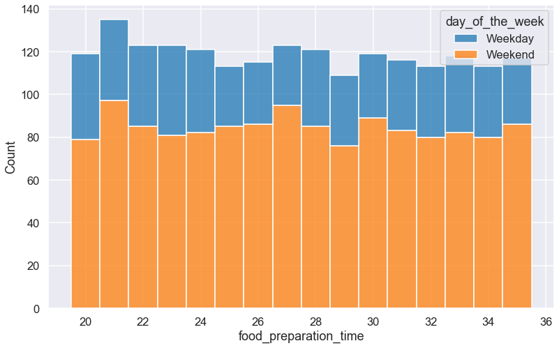

```python
# Display Food Prep Times by Day of the Week
plt.figure(figsize=(13, 8))
sns.histplot(data=df, x='food_preparation_time', discrete=True, hue='day_of_the_week', multiple='stack');
```

# Q12.1a Observation - `food_preparation_time` by `day_of_the_week`

- Even when separating the data by day of the week, the prep time still seems evenly distributed (see Q6.2)
- Not much of a pattern
- An order has a fairly equal probability of taking anywhere between 20 and 35 minutes of prep time, whether it's the weekend or weekday

# Q12.1b

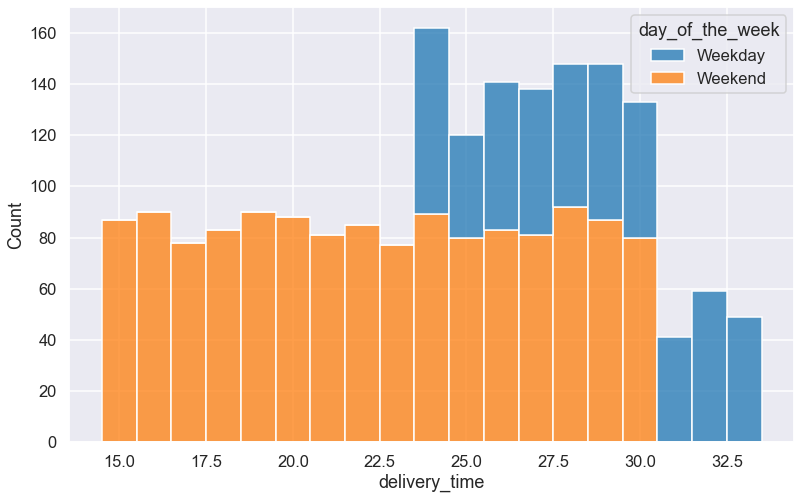

```python
# Display Delivery Times by Day of the Week
plt.figure(figsize=(13, 8))
sns.histplot(data=df, x='delivery_time', discrete=True, hue='day_of_the_week', multiple='stack');
```

# Q12.1b Observation - `delivery_time` by `day_of_the_week`

- The delivery times vary more widely than food prep times whether it's a weekday or weekend

# Q12.1c

```
Average total order time on Weekdays: 55.552102376599635
Average total order time on Weekends: 49.90673575129534
```

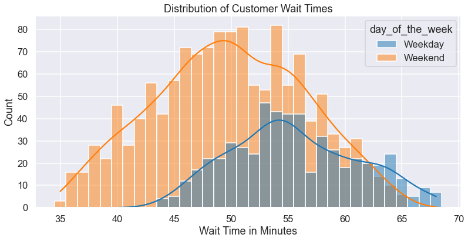

```python
# Display Total Times by Day of the Week
plt.figure(figsize=(13, 6))
sns.histplot(data=df, x='total_time', discrete=True, hue='day_of_the_week', multiple='layer', kde=True);
plt.title("Distribution of Customer Wait Times")
plt.xlabel("Wait Time in Minutes")
plt.savefig("time_day.jpg", bbox_inches='tight')


# Find average total order times
print("Average total order time on Weekdays:", df[df['day_of_the_week']=='Weekday']['total_time'].mean())
print("Average total order time on Weekends:", df[df['day_of_the_week']=='Weekend']['total_time'].mean())
```

# Q12.1c Observation - `total_time` by `day_of_the_week`

- As we saw before, there are more orders placed on the weekend than during weekdays
- Shorter wait times occur on the weekend
  - Could this be because drivers are combining trips when it's busier on the weekends?
- There is a higher distribution of longer wait times during weekdays
  - If we boosted the number of orders on weekdays, would the wait times become shorter?
- Avg total time on weekdays: 56 minutes
- Avg total time on weekends: 50 minutes

# Q12.2 - Are certain cuisine types more popular by day of the week?

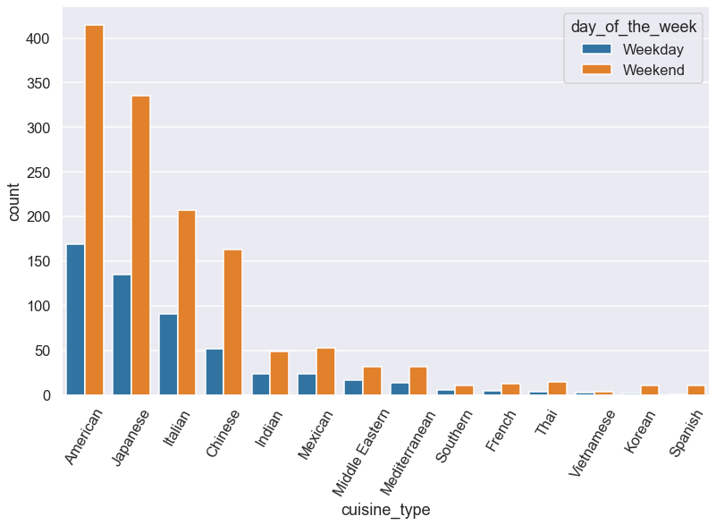

```python
# Is the popularity of cuisine type different whether it's the weekend or a weekday?

# Countplot of cuisines by day of the week, where the Weekday counts are sorted from highest to least
plt.figure(figsize=(13, 8))
sns.countplot(df['cuisine_type'], hue=df['day_of_the_week'], order = df[df['day_of_the_week']=='Weekday']['cuisine_type'].value_counts().index)
plt.xticks(rotation=60);
```

# Q12.2 Observation - `cuisine_type` by `day_of_the_week`

- The popularity in cuisine types seems about the same overall whether it's the weekday or weekend

# Q12.3a - Are long wait times related to poor reviews?

```python
# Are long wait times related to poor reviews?

# First remove the orders that don't have a rating
ratings = df.copy()
ratings = ratings[ratings['rating']!='Not given']

# Convert rating from object to integer
ratings['rating'] = ratings['rating'].astype('int64')

# Find the average total wait time for all orders rated a 3
ratings[ratings['rating']==3]['total_time'].describe()
```

```
count    188.000000
mean      51.989362
std        6.432695
min       35.000000
25%       47.750000
50%       52.000000
75%       56.000000
max       67.000000
Name: total_time, dtype: float64
```

# Q12.3a Observation - `rating` by `total_time`

- For orders given the lowest rating of 3, the average total wait time is 52
- This is just a half-minute longer than the average total wait time across the whole dataset
  - Not a substantial difference